# Tree thinking: A tutorial in R

# Learning objectives

- Introduce you to using trees to address evolutionary questions and to the R statistical environment
- Develop basic skills in tree visualisation
- Mapping character states and reconstructing ancestral characters
- Exploring convergent evolution
- Testing for correlated evolution

# Homework (before class)

An intro to R tutorial: http://lukejharmon.github.io/ilhabela/instruction/2015/07/02/Intro_to_R/

You can download the following R scripts to follow along:

Part I: tree_thinking_part1.R

Part II & III: tree_thinking_part2.R

# Introduction

## Habitat and trait diversity in Haemulid fishes

> Haemulidae is one of the ten most diverse, widespread, and conspicuous families within the largest sub-order of teleost fishes, the Percoidei. They are commonly called grunts, due to their ability to produce loud sounds by rubbing their pharyngeal teeth together. The family contains about 145 extant species currently classified in 17 nominal genera, grouped, based on morphological data, in two sub-families (Haemulinae, Plectorhynchinae). These two groups differ greatly in diversity and distribution. Haemulines, include most of the genera and are primarily distributed in the New World, with the exception of the genus Pomadasys. Haemulines are diverse in shape (elongate or stout), ecology (different feeding modes and prey items), and habitat (temperate reefs, coral reefs, sandy and muddy bottoms).”

> In general, haemulin grunts tend to be greyish and drab, with some exceptions such as the Caribbean porkfish, Anisotremus virginicus, which is mostly bright yellow with a few conspicuous black bars . On the other hand, sweetlips (Plectorhynchinae), are mostly restricted to the coral and rocky reefs of the Indo-Pacific and eastern Atlantic, and include approximately 50 species. They are morphologically uniform, with an elongated body, a round head, and a subterminal mouth. Sweetlips, colouring and patterning changes dramatically throughout their lives, and tend to be very distinctive, especially when compared to their haemulin counterparts.” [(Tavera *et al. BMC Evol Biol.* 2012)](https://bmcevolbiol.biomedcentral.com/articles/10.1186/1471-2148-12-57)

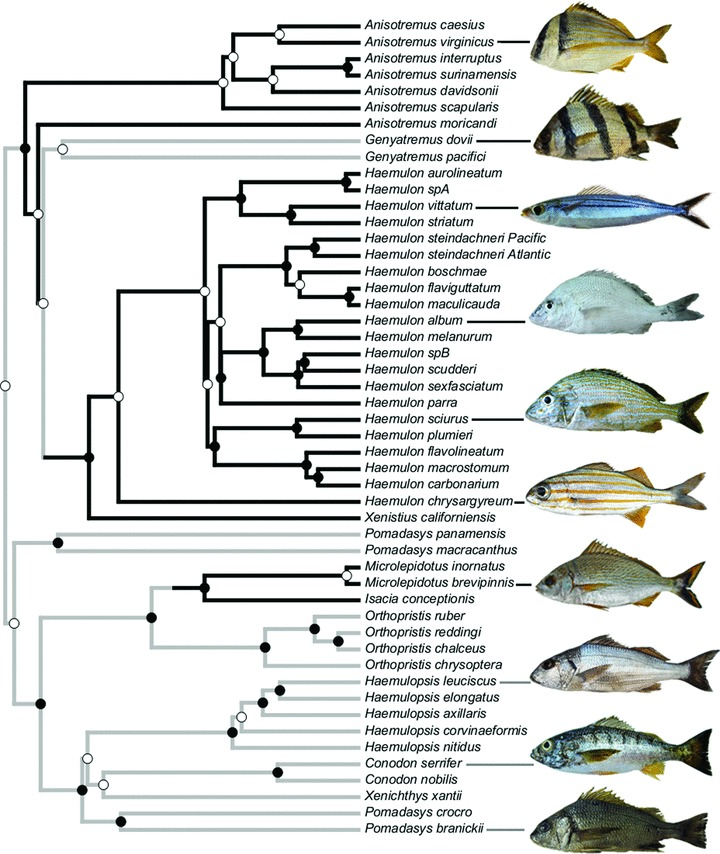

**Figure 1.** Possible mapping of fish living in reefs and not living in reefs in black and gray, respectively. Generated in SIMMAP v1.0 [(Bollback *BMC Bioinformatics* 2006)](https://link.springer.com/content/pdf/10.1186/1471-2105-7-88.pdf) Black circles indicate posterior probabilities of >0.95, while nodes with white circles show that support was below 0.95 or that the branch did not appear in the 50% majority-rule tree. Figure from [Price *et al. Evolution* 2012](http://onlinelibrary.wiley.com/doi/10.1111/j.1558-5646.2012.01773.x/abstract)

> “Grunts evolved over large geographic areas in two main habitats, non-reef (soft bottom: sandy and/or muddy) and reef (hard bottom: rocky and/or coral reef). The hard bottom habitat state occurs in Haemulon, Anisotremus, and Microlepidotus. Haemulinae grunts likely shifted their habitats from soft to hard bottom, and not vice versa, and they independently invaded hard substrates from soft bottoms three separate times (Figure 1).” [(Tavera *et al. BMC Evol Biol.* 2012)](https://bmcevolbiol.biomedcentral.com/articles/10.1186/1471-2148-12-57)

**Citations:**  
Bollback JP. SIMMAP: stochastic character mapping of discrete traits on phylogenies. *BMC Bioinformatics*. 2006;7:88. doi:10.1186/1471-2105-7-88.

Price SA, Tavera JJ, Near TJ, Wainwright PC. Elevated rates of morphological and functional diversification in reef-dwelling heamulid fishes. *Evolution (N Y)*. 2012;(McClanahan 1994):1-12. doi:10.5061/dryad.s049s.

Tavera J, P A, Balart EF, Bernardi G. Molecular phylogeny of grunts (Teleostei, Haemulidae), with an emphasis on the ecology, evolution, and speciation history of New World species. *BMC Evol Biol*. 2012;12(1):57. doi:10.1186/1471-2148-12-57.

# Part I – Importing and visualising trees in R

Install packages

```r
# to run, remove the comment character '#'
# install.packages("ape")
# install.packages("geiger")
# install.packages("nlme")
# install.packages("phytools")
```

Load necessary libraries

```r
library(ape)
library(geiger)
library(nlme)
library(phytools)
```

Let’s begin by simulating a tree. There are many options for doing this. We will read an example vertebrate tree from a Newick text string also called “bracket form” or “parenthetic format”.

```r
tt = "(((((((cow, pig),whale),(bat,(lemur,human))),(robin,iguana)),coelacanth),gold_fish),shark);"
```

We’ll use the ‘read.tree()’ function of the ape package. The tree is stored as an object called “vert.tree”.

```r
vert.tree <- read.tree(text=tt)
```

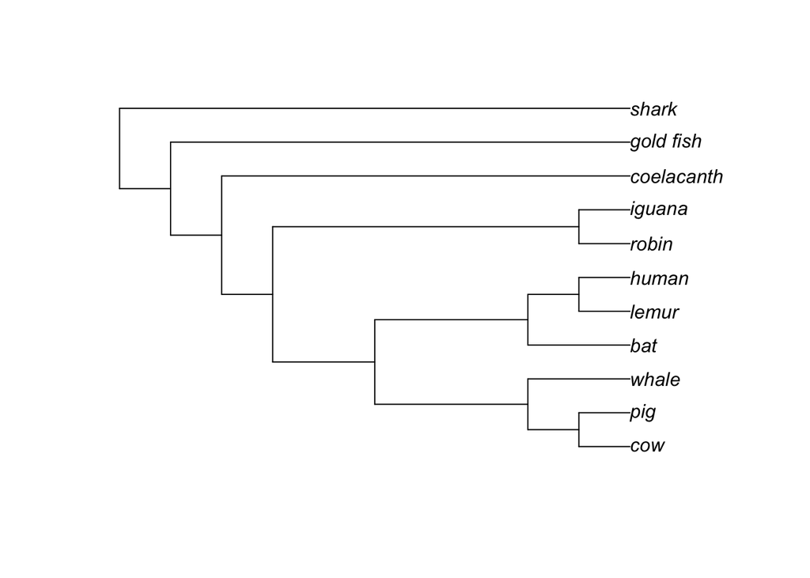

```r
plot(vert.tree) #"phylogram" is default
```

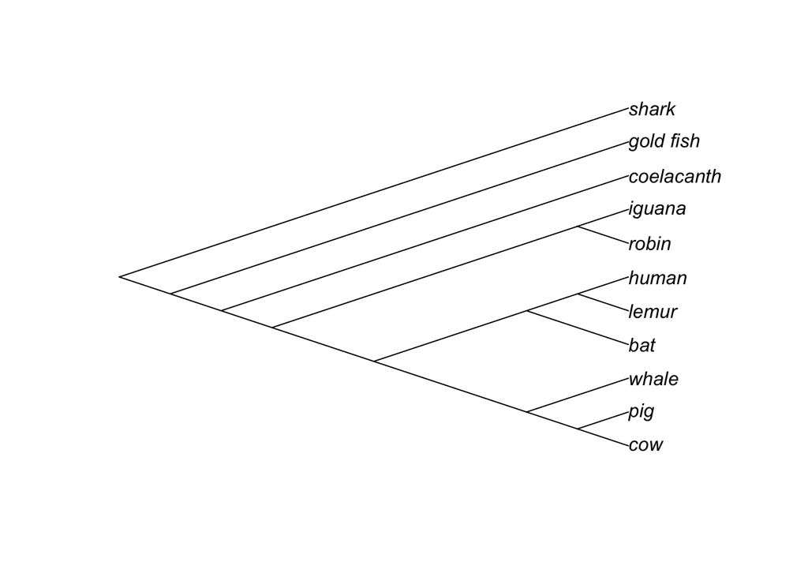

```r
plot(vert.tree,type="cladogram")
```

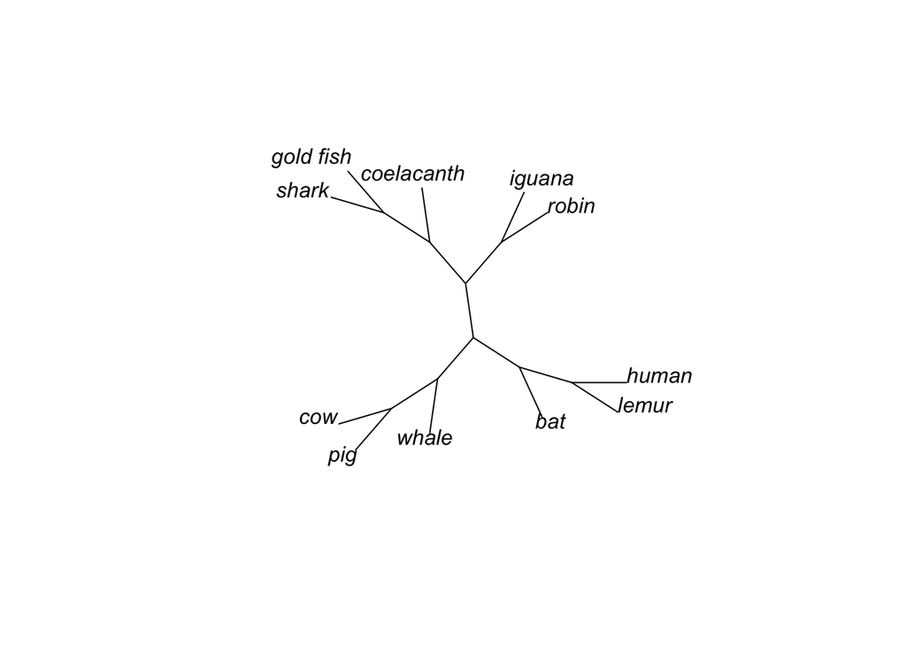

```r
plot(unroot(vert.tree),type="unrooted")
```

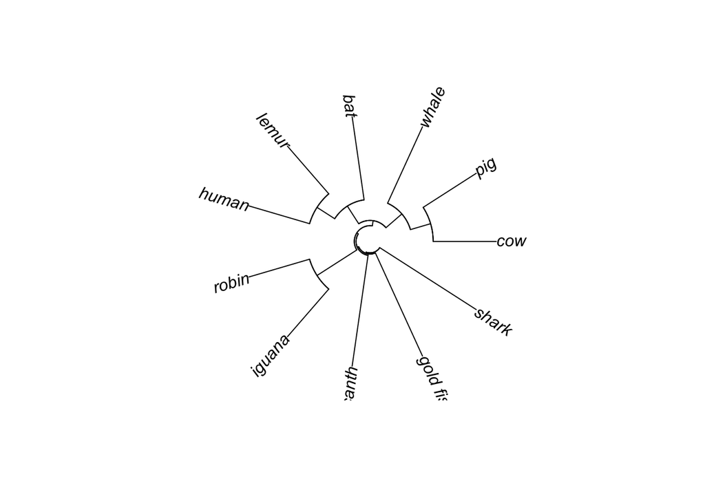

```r
plot(vert.tree,type="fan")
```

Before you continue, let’s pause for a second to explain Newick trees

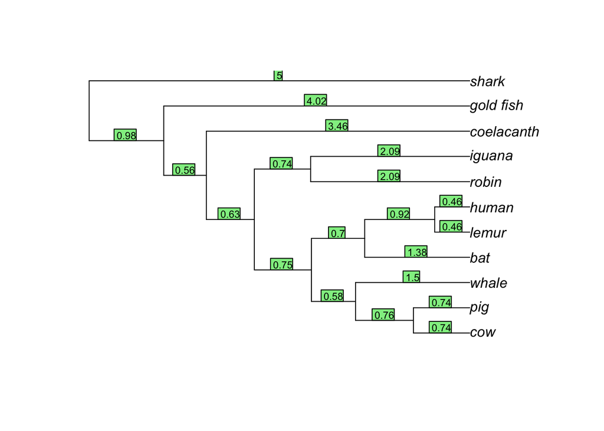

```r
tt2 <- "(((((((cow:0.74, pig:0.74):0.76,whale:1.5):0.58,(bat:1.38,(lemur:0.46,human:0.46):0.92):0.70):0.75,(robin:2.09,iguana:2.09):0.74):0.63,coelacanth:3.46):0.56,gold_fish:4.02):0.98,shark:5):0.58;"
tree <- read.tree(text=tt2)
plot(tree)
edgelabels(tree$edge.length,adj=c(0.5, -0.25),cex=0.7) # cex adjusts text size
```

The vector `tip.label` contains the labels for all the tips in the tree.

```r
tree$tip.label
```

```
##  [1] "cow"        "pig"        "whale"      "bat"        "lemur"
##  [6] "human"      "robin"      "iguana"     "coelacanth" "gold_fish"
## [11] "shark"
```

```r
# The order of tip.label is the order of the tips numbered 1 through n in edge
```

The integer `Nnode` contains the number of internal nodes in the tree, including the root of the tree if the tree is rooted.

```r
tree$Nnode
```

```
## [1] 10
```

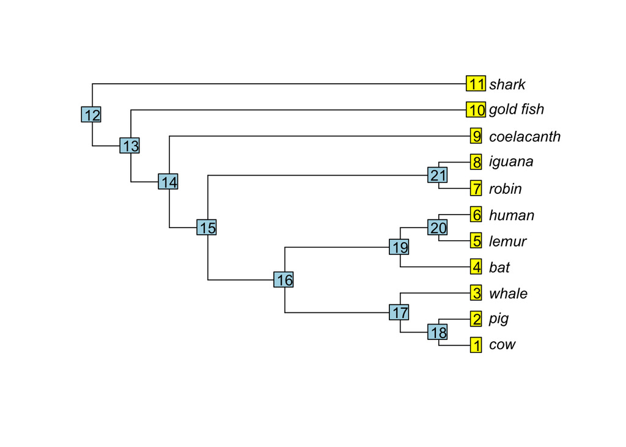

```r
plot(vert.tree,label.offset=0.3)
nodelabels() #adds node numbers
tiplabels() #adds tip numbers
```

We can see that all of the relationship information among the taxa in the tree is containing in the starting & ending nodes for each edge. Edges that share a common starting node number are descended from an immediate common ancestor, etc.

# Part II - Reconstructing ancestral character states

## Load and exlpore data

First, read in the tree and trait data

```r
gruntTree<-read.tree(url("https://bonnie-wall.github.io/tree_thinking/data/grunts.phy"))
gruntData<-read.csv(url("https://bonnie-wall.github.io/tree_thinking/data/grunts-edit.csv"), row.names=1)
```

Let’s see what this tree looks like

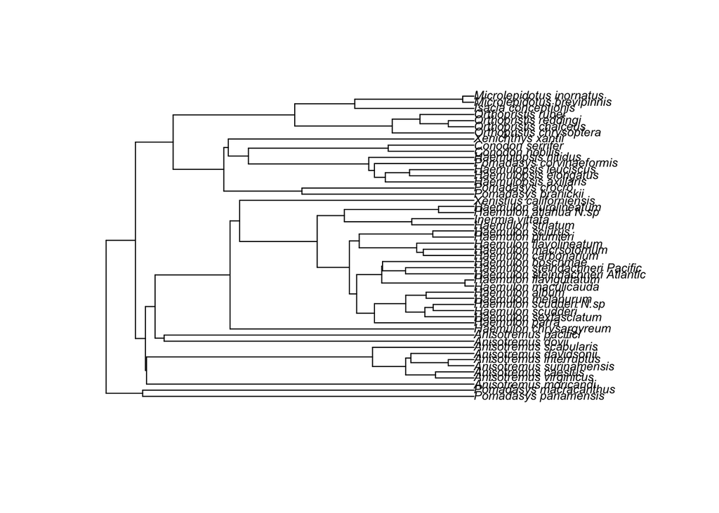

```r
plot(gruntTree, cex=0.7) # cex adjusts text size
```

Let’s look at our data

```r
head(gruntData)
```

```
##                          habitat habitat.names Standard_length
## Pomadasys_panamensis           0      non-reef          188.33
## Pomadasys_macracanthus         0      non-reef          213.00
## Anisotremus_moricandi          1          reef          127.00
## Anisotremus_virginicus         1          reef          210.00
## Anisotremus_caesius            1          reef          158.00
## Anisotremus_surinamensis       1          reef          157.00
##                          Raker_Length Suction_Index
## Pomadasys_panamensis             6.47          0.13
## Pomadasys_macracanthus           4.80          0.19
## Anisotremus_moricandi            3.10          0.40
## Anisotremus_virginicus           3.80          0.58
## Anisotremus_caesius              2.35          0.43
## Anisotremus_surinamensis         5.40          0.44
```

Geiger has a function to check that the names match between the tree and the data frame

```r
name.check(gruntTree, gruntData)
```

```
## [1] "OK"
```

Retrieve info on habitat and add names

```r
habitat<-gruntData[,2]
names(habitat)<-rownames(gruntData)
```

## Visualize the data

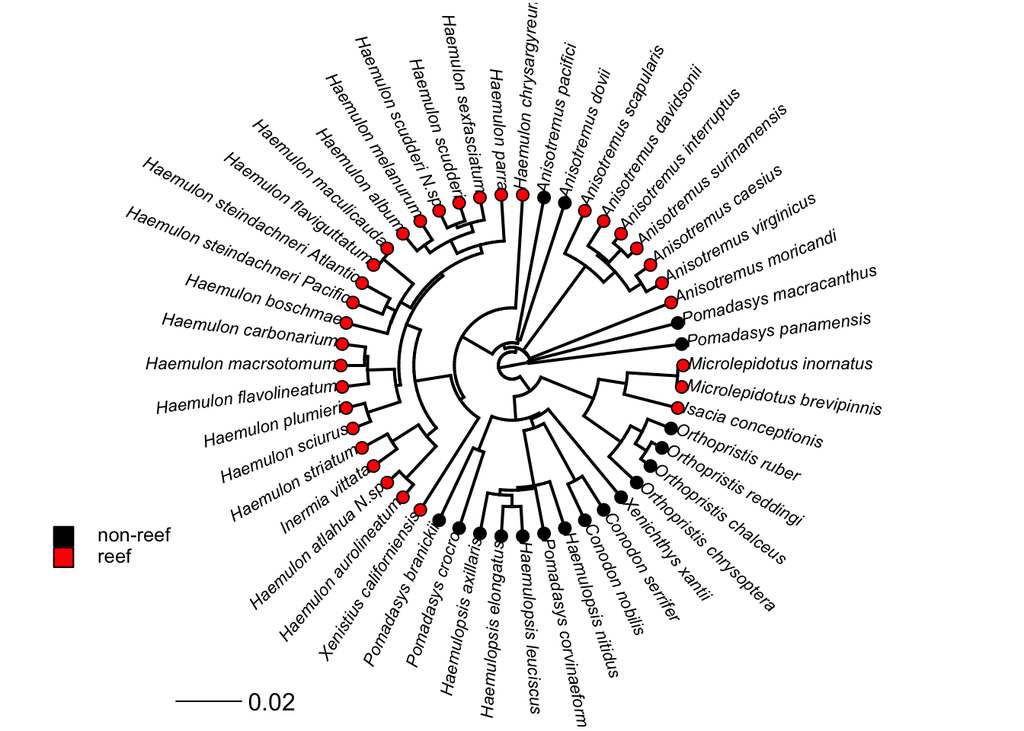

```r
# assign colors to habitat names
cols<-setNames(palette()[1:length(unique(habitat))],sort(unique(habitat)))
# plot tree
plotTree(gruntTree, type="fan", fsize=0.7,ftype="i"); add.scale.bar()
# add tip labels
tiplabels(pie=to.matrix(habitat,sort(unique(habitat))),piecol=cols,cex=0.3)
# add legend
add.simmap.legend(colors=cols,prompt=FALSE,x=0.9*par()$usr[1],
                  y=-max(nodeHeights(gruntTree)),fsize=0.8)
```

## Acestral state reconstruction of the habitat of grunts

Did grunts originate on reefs or away from reefs?

Next, let’s fit a single-rate model & reconstruct ancestral states at internal nodes in the tree. Calculate marginal likelihoods for ancestral states with an all-rates-equal model (ER)

```r
fitER<-ace(habitat,gruntTree,model="ER",type="discrete")
fitER
```

```
##
##     Ancestral Character Estimation
##
## Call: ace(x = habitat, phy = gruntTree, type = "discrete", model = "ER")
##
##     Log-likelihood: -13.4497
##
## Rate index matrix:
##          non-reef reef
## non-reef        .    1
## reef            1    .
##
## Parameter estimates:
##  rate index estimate std-err
##           1   4.9451  1.8926
##
## Scaled likelihoods at the root (type '...$lik.anc' to get them for all nodes):
## non-reef     reef
##  0.88857  0.11143
```

The element lik.anc gives us the marginal ancestral states, also known as the ‘empirical Bayesian posterior probabilities’

```r
round(fitER$lik.anc,3)
```

```
##       non-reef  reef
##  [1,]    0.889 0.111
##  [2,]    0.924 0.076
##  [3,]    0.861 0.139
##  [4,]    0.729 0.271
##  [5,]    0.714 0.286
##  [6,]    0.008 0.992
##  [7,]    0.000 1.000
##  [8,]    0.000 1.000
##  [9,]    0.000 1.000
## [10,]    0.000 1.000
## [11,]    0.727 0.273
## [12,]    0.760 0.240
## [13,]    0.035 0.965
## [14,]    0.020 0.980
```

[output cut: 35 more lines]

It is fairly straightforward to overlay these posterior probabilities on the tree:

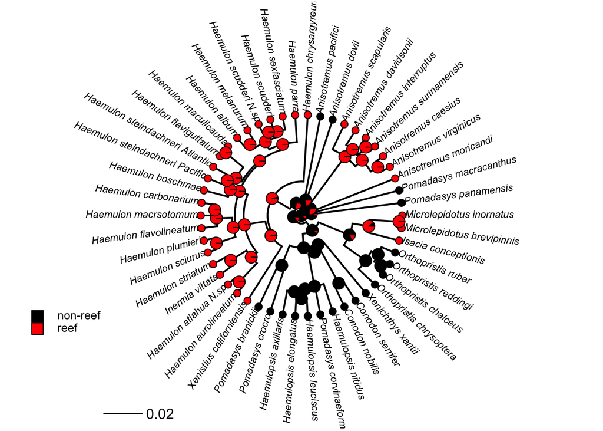

```r
# plot tree
plotTree(gruntTree, type="fan", fsize=0.7,ftype="i"); add.scale.bar()
# add tip labels
tiplabels(pie=to.matrix(habitat,sort(unique(habitat))),piecol=cols,cex=0.3)
# add legend
add.simmap.legend(colors=cols,prompt=FALSE,x=0.9*par()$usr[1],
                  y=-max(nodeHeights(gruntTree)),fsize=0.8)
# add nodelabels (pie charts representing likelihoods)
nodelabels(node=1:gruntTree$Nnode+Ntip(gruntTree),
           pie=fitER$lik.anc,piecol=cols,cex=0.5)
```

## Stochastic character mapping

An alternative approach to the one outline above is to use an MCMC approach to sample character histories from their posterior probability distribution. This is called stochastic character mapping (Huelsenbeck et al. 2003). The model is the same but in this case we get a sample of unambiguous histories for our discrete character’s evolution on the tree - rather than a probability distribution for the character at nodes.

For instance, given the data simulated above - we can generate the stochastic character map as follows:

```r
# simulate single stochastic character map using empirical Bayes method
mtree<-make.simmap(gruntTree,habitat,model="ER")
```

```
## make.simmap is sampling character histories conditioned on the transition matrix
##
## Q =
##           non-reef      reef
## non-reef -4.945107  4.945107
## reef      4.945107 -4.945107
## (estimated using likelihood);
## and (mean) root node prior probabilities
## pi =
## non-reef     reef
##      0.5      0.5
```

```
## Done.
```

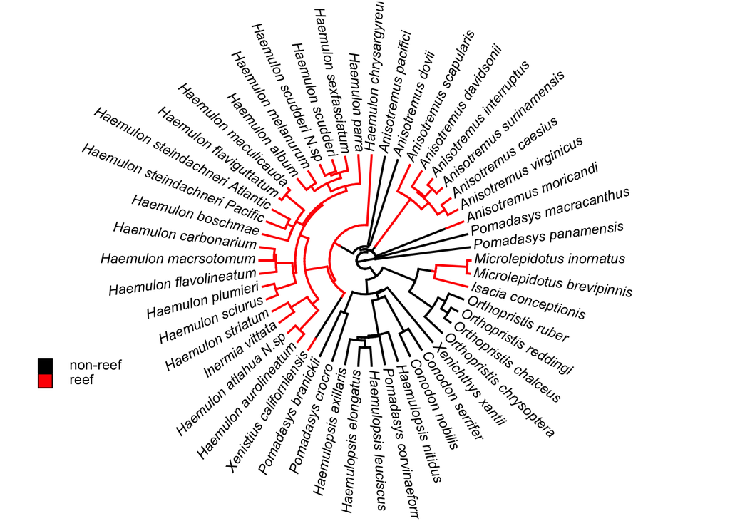

```r
plotSimmap(mtree,cols,type="fan",fsize=0.8,ftype="i")

add.simmap.legend(colors=cols,prompt=FALSE,x=0.9*par()$usr[1],
                  y=-max(nodeHeights(gruntTree)),fsize=0.8)
```

# Part III - Testing for correlated evolution of continuous traits

Is there a correlation between trait 1 and trait 2?

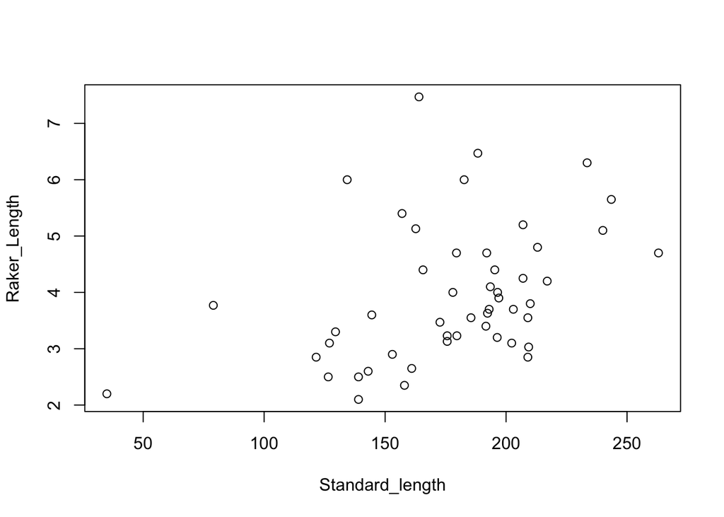

```r
par(mar=c(5.1,4.1,4.1,2.1)) # sets margins
plot(Raker_Length~Standard_length, data=gruntData)
```

It looks like there might be…

## Phylogenetically independent contrasts (PICs)

We can do this analysis easily with the PICs method of Felsenstein (1985) for estimating the evolutionary correlation between characters. Felsenstein (1985) identified that the data for species cannot be treated as independent data points from the point of view of statistical analysis.

```r
# Extract columns
Standard_length <- gruntData[, "Standard_length"]
Raker_Length <- gruntData[, "Raker_Length"]

# Give them names
names(Standard_length) <- names(Raker_Length) <- rownames(gruntData)

# Calculate phylogenetically independent contrasts (PICs)
t1Pic <- pic(Standard_length, gruntTree)
t2Pic <- pic(Raker_Length, gruntTree)

# Make a model
picModel <- lm(t1Pic ~ t2Pic - 1)

# Is it significant?
summary(picModel)
```

```
##
## Call:
## lm(formula = t1Pic ~ t2Pic - 1)
##
## Residuals:
##     Min      1Q  Median      3Q     Max
## -895.88 -138.42   18.62  162.04  689.88
##
## Coefficients:
##       Estimate Std. Error t value Pr(>|t|)
## t2Pic   19.143      3.556   5.383 2.16e-06 ***
## ---
## Signif. codes:  0 '***' 0.001 '**' 0.01 '*' 0.05 '.' 0.1 ' ' 1
##
## Residual standard error: 300.8 on 48 degrees of freedom
## Multiple R-squared:  0.3765, Adjusted R-squared:  0.3635
## F-statistic: 28.98 on 1 and 48 DF,  p-value: 2.161e-06
```

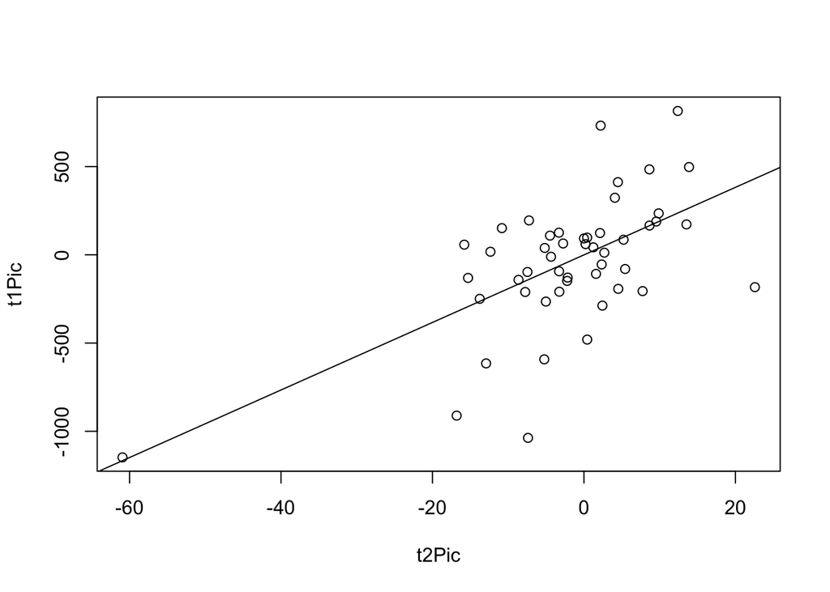

```r
# plot results
plot(t1Pic ~ t2Pic)
abline(a = 0, b = coef(picModel))
```

**Is the correlation between trait 1 and trait 2 significant?**

## Phylogenetic generalized least squares (PGLS)

This whole procedure can be carried out more simply and with more flexibility using PGLS.

Probably one of the most frequently used phylogenetic comparative methods is phylogenetic generalized least squares (PGLS). PGLS allows for the analysis of evolutionary associations between traits and can also handle mutiple predictor variables. The method was first introduced by Grafen (1989), as a generalization of Felsenstein’s independent contrasts.

### Brownian Correlation Strucure

Now, what is Brownian motion (BM)? It’s basically a simple continuous stochastic (=probabilistic) process that describes the direction and magnitude of motion at any given point in time. Direction and magnitude of motion are completely independent from the previous history of motion. We can apply this model to the evolution of a trait. For example, we can say that at each instant in time the trait value can increase or decrease, and the direction and the magnitude of change is not influenced by the previous history of the trait.

Assuming Brownian motion, the expected covariance is directly proportional to the amount of shared evolutionary history. We will not go into statistical details in this tutorial but rather carry out a basic PGLS. If we were to assume a Brownian motion model of evolution, then we could use the trait data and tree in a call to the gls function in the nlme package:

```r
pglsResult<-gls(Standard_length~Raker_Length,
                cor=corBrownian(1, phy=gruntTree),
                data=gruntData,
                method="ML")
```

### Martins Correlation Structure

The Ornstein-Uhlenbeck (OU) process is an extension of Brownian motion. In addition to stochastic displacement, there is an optimal trait value and a pull towards that optimum. We can also assume that the error structure follows an OU model rather than Brownian motion and apply Martins and Hansen’s (1997) covariance structure:

```r
pglsResultOU<-gls(Standard_length~Raker_Length,
                  cor=corMartins(1, phy=gruntTree, fixed=T),
                  data=gruntData,
                  method="ML")
```

### Pagel’s “lambda” Correlation Structure

Another method for testing phylogenetic signal is Pagel’s lambda. Lambda is a tree transformation that stretches tip branches relative to internal branches, making the tree more and more like a complete polytomy. If our estimated lambda = 0, then the traits are inferred to have no phylogenetic signal. Lambda = 1 corresponds to a Brownian motion model; 0 < lambda < 1 is in between.

```r
pglsResultPagel<-gls(Standard_length~Raker_Length,
                     cor=corPagel(1, phy=gruntTree, fixed=T),
                     data=gruntData,
                     method="ML")
```

### Selecting the best model

Another possibility to select the best model is the Akaike Information Criterion (AIC). The chosen model is the one that minimizes the Kullback-Leibler distance between the model and the truth. It’s based on information theory, but a heuristic way to think about it is as a criterion that seeks a model that has a good fit to the truth but few parameters. (http://brianomeara.info/tutorials/aic/)

The best model will have the lowest AIC, choose that:

```r
anova(pglsResult, pglsResultOU, pglsResultPagel)
```

```
##                 Model df      AIC      BIC    logLik
## pglsResult          1  3 521.1901 526.9261 -257.5950
## pglsResultOU        2  3 524.9394 530.6755 -259.4697
## pglsResultPagel     3  3 521.1901 526.9261 -257.5950
```

```r
anova(pglsResultPagel)
```

```
## Denom. DF: 48
##              numDF  F-value p-value
## (Intercept)      1 47.15463  <.0001
## Raker_Length     1 28.97927  <.0001
```

**Is there is a relationship?**

# Other helpful links (after class)

This tutorial has been adapted from the following:

- Luke Harmon: http://lukejharmon.github.io/ilhabela/
- Lars Schmitz: http://schmitzlab.info/code.xhtml

Importing and visualising trees in R:

https://lukejharmon.github.io/ilhabela/instruction/2015/07/02/introduction-phylogenies-in-R/

http://schmitzlab.info/phylo.html

http://schmitzlab.info/phylo2.html

Map – discrete – characters and reconstruct ancestral traits:

http://lukejharmon.github.io/ilhabela/instruction/2015/07/03/ancestral-states-2/

http://lukejharmon.github.io/ilhabela/2015/07/03/trait-challenge/

http://schmitzlab.info/asr.html

Testing for correlated evolution of continuous traits:

http://lukejharmon.github.io/ilhabela/instruction/2015/07/03/PGLS/

http://schmitzlab.info/pgls.html

Additional plotting info:

http://lukejharmon.github.io/ilhabela/instruction/2015/07/05/plotting-methods/